Home: http://manmustbecool.github.io/MyWiki/

# java Collection

## 0.1 Collection

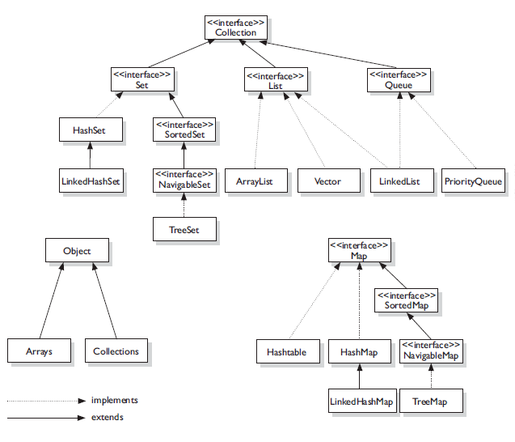

images-Collection-Framework.PNG

### 0.1.1 List

- cares about index
- index related methods like get(int index) are available only in List based classes
- lists are ordered by index position
- can add elements at a particular index or at the end of the list

**ArrayList**

- growable array
- gives fast iteration and fast random access
- ordered but not sorted
- implements RandomAccess interface(marker interface), hence ArrayList supports fast(generally constant time) random access
- choose this over LinkedList when you need fast iteration but aren’t as likely to be doing a lot of insertion and deletion
- methods are not synchronized

**Vector**

- holdover from earliest days of java; Vector and Hashtable were the original collections (rest were added at 1.2 and 1.4)
- same as ArrayList but methods are synchronized for thread safety
- due to synchronized, Vector is slow in performance
- thread safety can be obtained from Collections utility methods as well instead of using Vector
- Vector is the only class other than ArrayList to implement RandomAccess

**LinkedList**

- is ordered by index position(like ArrayList), except that elements are doubly-linked to one another methods to add/remove from beginning or end
- easy choice to implement stack or queue
- iterates more slowly than ArrayList
- but a good choice for fast insertion and deletion
- as of java 5, it was enhanced to implement Queue interface as well; hence supports peek(), poll(), offer() and such methods

### 0.1.2 Set

- cares about uniqueness
- doesn’t allow duplicates
- bases itself on equals() method implementation

**HashSet**

- unsorted and unordered set
- uses hashcode of the object being inserted; the more efficient hashCode() implementation, the better access performance
- use this when you want no duplicates and don’t care about order when you iterate through the elements

**LinkedHashSet**

- an ordered version of HashSet
- maintains doubly-linked list across all elements
- if you care about iteration order, use this
- it lets you iterate through in the order in which elements were inserted(or added)

when using HashSet or LinkedHashSet, you must override hashCode(), otherwise uniqueness of objects is not guaranteed

**TreeSet**

- is one of the two sorted collections (the other being TreeMap)
- uses Red-Black tree structure(special binary search tree with minimum possible height)
- guarantees that the elements will be in ascending order according to natural order
- lets you specify your own ordering rules by using Comparable or Comparator
- as of java 6, TreeSet also implements NavigableSet

### 0.1.3 Map

- cares about unique identifiers for each value
- both key and value are objects
- relies on equals() to determine two keys are same or not

**HashMap**

- unsorted unordered map
- access performance depends on the hashCode() implementation for your keys
- allows one null key and multiple null values

**Hashtable**

- legacy class
- synchronized counter part to HashMap
- doesn’t allow null keys or values(throws NullPointerException in such cases)

**LinkedHashMap**

- maintains insertion order(optionally access order, thru a flag to the constructor)
- slower than HashMap for adding removing elements
- faster iteration than HashMap

**TreeMap**

- sorted Map and hence ordered in the natural order
- lets you define custom sort order through Comparable or Comparator interfaces
- as of java 6, implements NavigableMap

### 0.1.4 Queue

- list of TO-DOs
- typically thought of as FIFO(first-in first-out)
- supports standard Collection methods + methods to add/subtract/review queue elements

**PriorityQueue**

- basic queues can be implemented with LinkedList
- purpose of PriorityQueue is to create “priority-in priority-out” queue as opposed to “first-in first-out)
- elements are ordered according to natural order or according to the Comparator set
- elements that are sorted first are accessed first; ordering represents the relative priority between elements

## 0.2 Basic

### 0.2.1 Compare and Sort

Comparable

- java.lang.Comparable
- int obj1.compareTo(obj2)
- returns negative int when obj2 is greater, positive int when obj1 is greater, zero when both are equal
- you must modify the class whose instances you want to sort
- only one sort sequence can be done
- implemented frequently by APIs such as String, Wrapper classes, Date, Calendar, etc

Comparator

- java.util.Comparator
- int compare(obj1, obj2)
- return value is same as Comparable
- you build a class separate from the class whose instances you want to sort
- many sort sequences can be created
- meant to be implemented by third party classes
- both Comparable and Comparator are interfaces; they are appropriately put in different packages based on their purpose

```
class Order implements Comparable<Order> {
    private int orderId;
    private int amount;
    private String customer;

    // Sorting on orderId is natural sorting for Order.
    @Override
    public int compareTo(Order o) {
        return this.orderId > o.orderId ? 1 : (this.orderId < o.orderId ? -1 : 0);
    }

    //Comparator implementation to Sort Order object based on Amount
    public static class OrderByAmount implements Comparator<Order> {
        @Override
        public int compare(Order o1, Order o2) {
            return o1.amount > o2.amount ? 1 : (o1.amount < o2.amount ? -1 : 0);
        }
    }

    // Anohter Comparator implementation based upon customer name.
    public static class OrderByCustomer implements Comparator<Order> {
        @Override
        public int compare(Order o1, Order o2) {
            return o1.customer.compareTo(o2.customer);
        }
    }
}
```

Collection sort:

```
// use comparable
Collections.sort(orders);
Collections.sort(orders, Collections.reverseOrder());

// use comparator
Collections.sort(orders, new Order.OrderByAmount());
Collections.sort(termsList, Collections.reverseOrder(new Order.OrderByCustomer()));
```

- `Arrays.sort()` provides sorting capability for arrays in the same way Collections.sort() provides
- both Arrays.sort() and Collections.sort() are static methods; both alter the same object they are sorting and do not return result as a separate object;
- loads of sort() overloaded methods to sort primitive data arrays in their natural order without the use of Comparator
- if two objects that are not comparable present in the array or collection, the sort will fail

String natural order: * space comes before letters * uppercase letters come before lowercase letters

### 0.2.2 Collection and Array conversion

```
// Collection to Arrays
String [] countries = list.toArray(new String[list.size()]);

// Arrays to Collection
List list1 = Arrays.asList(countries);
```

- Arrays.asList() copies an array into a List; this list is backed by the original array; changes to the returned list write through to the array; that is changing either the array or the list, updates the other automatically; array and list both become joined at the hip;(makes the given array as the internal array for the new list)

### 0.2.3 Searching Array and Collection

- searches are performed using the binarySearch() method
- successful search returns the int index of the element searched
- unsuccessful search returns insertion point(index) as return value; insertion point is where the searched element can be added without affecting the sorted order of other elements
- 0 and positive return values indicate successful search
- negative return value indicates insertion point on unsuccessful search
- since 0 is not available for negative range, -1 indicates 0th index, -2 indicates 1st index and so on; so insertion point is calculated by [-n -1] where n is the signed insertion index returned.
- the collection/array being searched must be sorted before you can search it
- attempting to search an unsorted array or collection will result in unpredictable results(not compiler error :))
- the collection/array sorted in natural order can only be searched in natural order using binarySearch() method; hence no Comparator is allowed
- comparators cannot be used while searching arrays of primitives(nobody wants your own way of arranging integers, strings, etc)
- the same comparator used to sort has to be used while searching; otherwise the consequences are dire
- even trying to search an array or collection that has been reverse-sorted(descending) will return incorrect result

SEARCH RULE –> SORT : SAME_COMPARATOR : ASCENDING

```
int index = Collections.binarySearch(list, "John");

int index = Collections.binarySearch(list, key, comparator)
```

### 0.2.4 Sub Collection

`.subList()/.subSet()/.sub...` methods only returns a view of the portion of the original collection. The sub list will be updated if the original list be updated, and vice versa.

### 0.2.5 Synchronized collection

Collection synchronized wrapper method return a a wrapped instance which has all get, put methods synchronized

```
Collections.synchronizedMap(hashMap)

Collections.synchronizedList(list)
```

ConcurrentHashMap: * ConcurrentHashMap stores key-value pair is stored in different segments. Different segments can be locked by different threads in high concurrent executions. * In Collections.synchronizedMap, the whole hash map only can be locked by one thread each time.

ref: http://murkymind.blogspot.ie/2012/05/gist-notes-7-java-generics-and.html

.